# Iris Data Exploration Rmarkdown

Matthew Pecsok

Created: 4/19/2023 MP

# 1 Data description

When learning a new technique it’s often helpful to start with a dataset that is well known and that has characteristics useful in the context of the technique. The IRIS dataset is one of the best datasets for introductory model building because it has 3 classes, one of which is linear separable and the other two are not.

https://en.wikipedia.org/wiki/Iris_flower_data_set

The target variable is the class of the flowers. A column called “species”

We will use this notebook to learn the attributes of the dataset.

In addition pay CLOSE attention to the code syntax throughout. You will need to learn this syntax quickly.

```r
library(tidyverse)
library(psych)
```

# 2 help!

get help on the iris dataset included with R. these don’t output to Rmarkdown, rather they pull up help pages when you run them in your browser (via knit) or in the IDE.

```r
#?iris
```

```r
#?str
```

## 2.1 BULLET POINTS unordered.

- get the structure of the dataset.
- str shows we have 150 rows (observations) and 5 columns (variables) the datatype of each of the columns displays some of the observations

The %>% sends the dataset to the str() function.

# 3 Learning the STRUCTURE of your data

## 3.1 str

```r
iris %>% str()
```

```
## 'data.frame':    150 obs. of  5 variables:
##  $ Sepal.Length: num  5.1 4.9 4.7 4.6 5 5.4 4.6 5 4.4 4.9 ...
##  $ Sepal.Width : num  3.5 3 3.2 3.1 3.6 3.9 3.4 3.4 2.9 3.1 ...
##  $ Petal.Length: num  1.4 1.4 1.3 1.5 1.4 1.7 1.4 1.5 1.4 1.5 ...
##  $ Petal.Width : num  0.2 0.2 0.2 0.2 0.2 0.4 0.3 0.2 0.2 0.1 ...
##  $ Species     : Factor w/ 3 levels "setosa","versicolor",..: 1 1 1 1 1 1 1 1 1 1 ...
```

```r
# str(iris)
```

## 3.2 nrow

Get the number of rows.

```r
iris %>% summarise(n = n()) # returns a tibble
```

```
##     n
## 1 150
```

```r
#nrow(iris) # returns a vector with one integer
```

## 3.3 ncol

Get the number of columns.

```r
iris %>% ncol()
```

```
## [1] 5
```

```r
#ncol(iris)
```

## 3.4 head

```r
iris %>% head() # defaults to 6 rows.
```

```
##   Sepal.Length Sepal.Width Petal.Length Petal.Width Species
## 1          5.1         3.5          1.4         0.2  setosa
## 2          4.9         3.0          1.4         0.2  setosa
## 3          4.7         3.2          1.3         0.2  setosa
## 4          4.6         3.1          1.5         0.2  setosa
## 5          5.0         3.6          1.4         0.2  setosa
## 6          5.4         3.9          1.7         0.4  setosa
```

```r
#head(iris)
```

```r
iris %>% head(n=3) # Show first 3 rows.
```

```
##   Sepal.Length Sepal.Width Petal.Length Petal.Width Species
## 1          5.1         3.5          1.4         0.2  setosa
## 2          4.9         3.0          1.4         0.2  setosa
## 3          4.7         3.2          1.3         0.2  setosa
```

```r
#head(iris,n=3)
```

## 3.5 tail

```r
iris %>% tail(n=3) # Show LAST 3 rows.
```

```
##     Sepal.Length Sepal.Width Petal.Length Petal.Width   Species
## 148          6.5         3.0          5.2         2.0 virginica
## 149          6.2         3.4          5.4         2.3 virginica
## 150          5.9         3.0          5.1         1.8 virginica
```

```r
#tail(iris,n=3)
```

# 4 DESCRIPTIVE Statistics and plots

## 4.1 summary

Shows summary statistics of the columns. This works great for numeric columns and we get median, min etc. For categorical columns we just see the counts.

```r
iris %>% summary()
```

```
##   Sepal.Length    Sepal.Width     Petal.Length    Petal.Width
##  Min.   :4.300   Min.   :2.000   Min.   :1.000   Min.   :0.100
##  1st Qu.:5.100   1st Qu.:2.800   1st Qu.:1.600   1st Qu.:0.300
##  Median :5.800   Median :3.000   Median :4.350   Median :1.300
##  Mean   :5.843   Mean   :3.057   Mean   :3.758   Mean   :1.199
##  3rd Qu.:6.400   3rd Qu.:3.300   3rd Qu.:5.100   3rd Qu.:1.800
##  Max.   :7.900   Max.   :4.400   Max.   :6.900   Max.   :2.500
##        Species
##  setosa    :50
##  versicolor:50
##  virginica :50
##
##
##
```

```r
#summary(iris)
```

## 4.2 binning data

Quantile, quintile

```r
iris$Sepal.Length %>% quantile()
```

```
##   0%  25%  50%  75% 100%
##  4.3  5.1  5.8  6.4  7.9
```

```r
iris$Sepal.Length %>% quantile(probs = seq(0,1, 0.2))
```

```
##   0%  20%  40%  60%  80% 100%
## 4.30 5.00 5.60 6.10 6.52 7.90
```

```r
iris$Sepal.Length %>% quantile(probs = seq(0,1, 0.1))
```

```
##   0%  10%  20%  30%  40%  50%  60%  70%  80%  90% 100%
## 4.30 4.80 5.00 5.27 5.60 5.80 6.10 6.30 6.52 6.90 7.90
```

```r
#quantile(iris$Sepal.Length)
```

### 4.2.1 Numbered bullets

we just showed data split into bins by

1. 25% increments/bins (Quartiles)
2. 20% increments/bins (Quintiles or Pentiles)
3. 10% increments/bins (Deciles)

For the curious student there are many different quantiles. Learn more names here. https://en.wikipedia.org/wiki/Quantile#:~:text=Common%20quantiles%20have%20special%20names,than%20for%20the%20cut%20points.

## 4.3 standard deviation

```r
iris %>% summarize(sd(Sepal.Width))
```

```
##   sd(Sepal.Width)
## 1       0.4358663
```

```r
#sd(iris[,c(2)])
```

## 4.4 variance

```r
iris %>% summarize(var(Sepal.Width))
```

```
##   var(Sepal.Width)
## 1        0.1899794
```

```r
#var(iris[,c(2)])
```

## 4.5 histogram

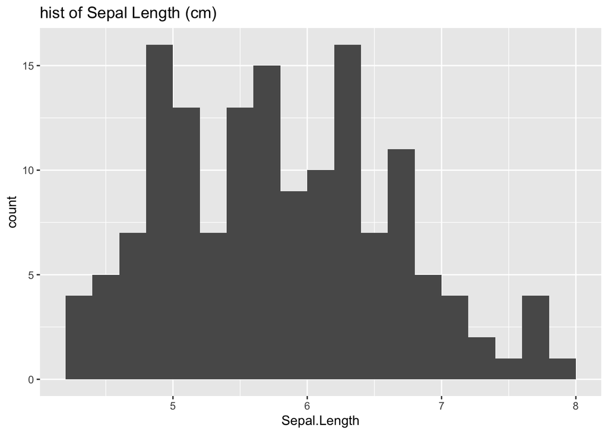

```r
iris %>%
  ggplot(aes(x=Sepal.Length)) +
  geom_histogram(bins=19) +
  ggtitle('hist of Sepal Length (cm)')
```

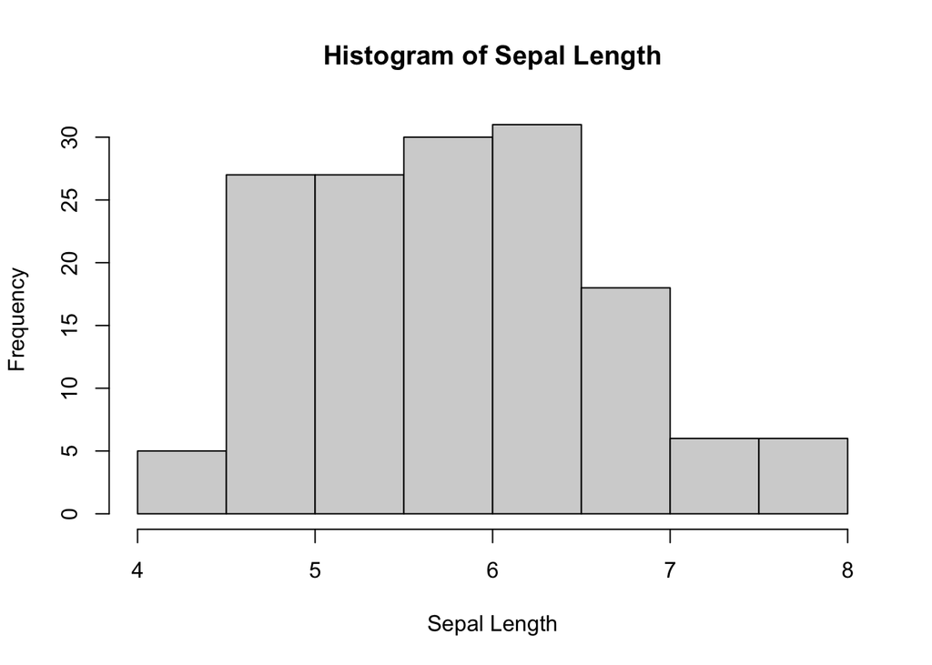

```r
hist(iris$Sepal.Length, main = "Histogram of Sepal Length",
     xlab = "Sepal Length")
```

## 4.6 boxplots

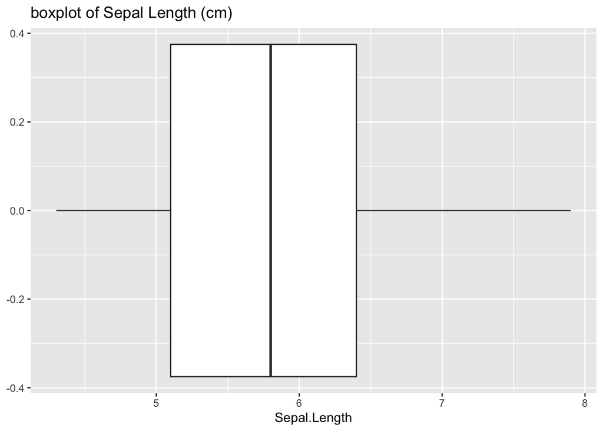

```r
iris %>%
  ggplot(aes(x=Sepal.Length)) +
  geom_boxplot() +
  ggtitle('boxplot of Sepal Length (cm)')
```

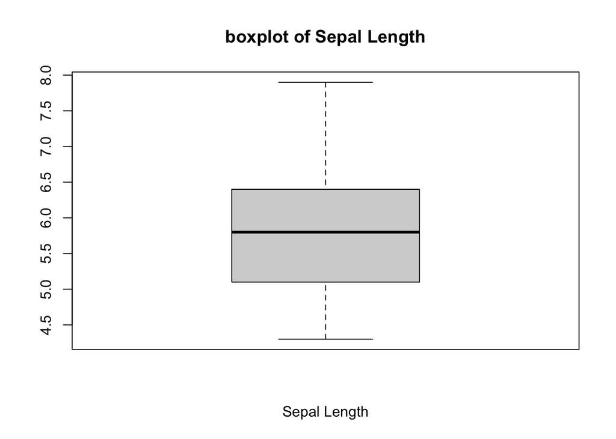

```r
boxplot(iris$Sepal.Length, main = "boxplot of Sepal Length",
     xlab = "Sepal Length")
```

# 5 Explore FACTOR/CATEGORICAL variables

```r
iris$Species %>% is.factor()
```

```
## [1] TRUE
```

```r
#is.factor(iris$Species)
```

## 5.1 summary

```r
iris$Species %>% summary()
```

```
##     setosa versicolor  virginica
##         50         50         50
```

## 5.2 nlevels

```r
iris$Species %>% nlevels()
```

```
## [1] 3
```

## 5.3 count

```r
iris %>% count(Species)
```

```
##      Species  n
## 1     setosa 50
## 2 versicolor 50
## 3  virginica 50
```

## 5.4 proportions

```r
iris$Species %>% table()  %>% prop.table() %>% round(digits=3)
```

```
## .
##     setosa versicolor  virginica
##      0.333      0.333      0.333
```

```r
iris %>%
  group_by(Species) %>%
  summarize(n = n()) %>%
  mutate(prop = n/sum(n))
```

```
## # A tibble: 3 × 3
##   Species        n  prop
##   <fct>      <int> <dbl>
## 1 setosa        50 0.333
## 2 versicolor    50 0.333
## 3 virginica     50 0.333
```

```r
round(prop.table(table(iris$Species)),2)
```

```
##
##     setosa versicolor  virginica
##       0.33       0.33       0.33
```

## 5.5 barplots

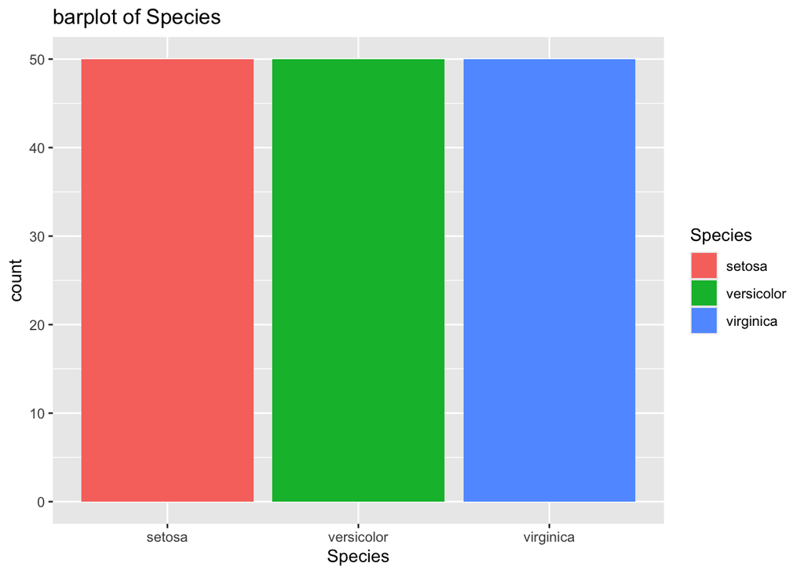

```r
iris %>%
  ggplot() +
  geom_bar(aes(x=Species,fill=Species)) +
  ggtitle('barplot of Species')
```

## proportion plots

This is just one of many ways to calculate the proportions in R and tidyverse.

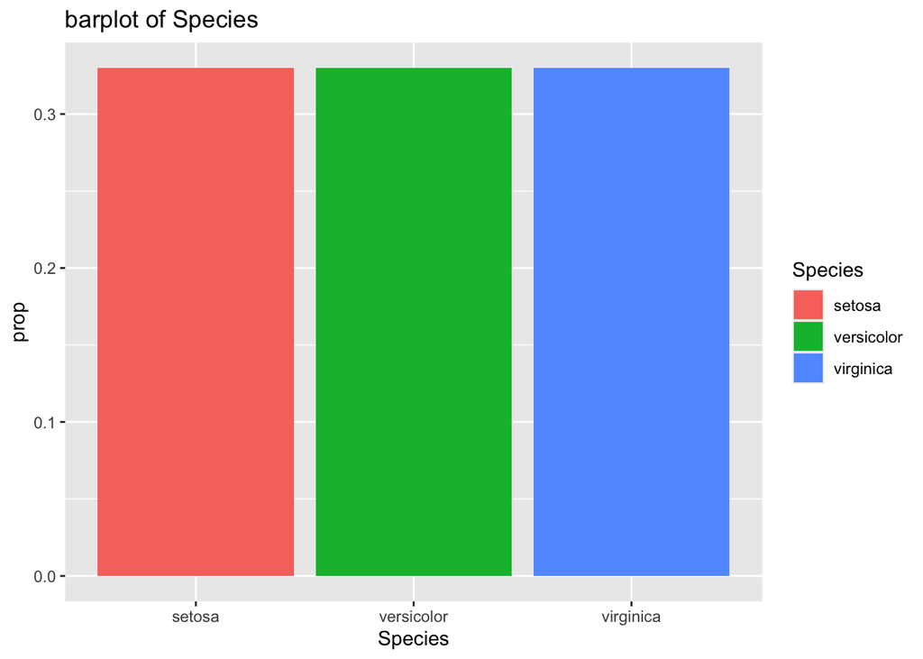

```r
iris %>%
  count(Species) %>%
  mutate(total_n=sum(n)) %>%
  mutate(prop = round(n/total_n,2)) %>%
  ggplot() +
  geom_col(aes(x=Species,y=prop,fill=Species)) +
  ggtitle('barplot of Species')
```

# 6 Relationships BETWEEN columns

## 6.1 pairs panels

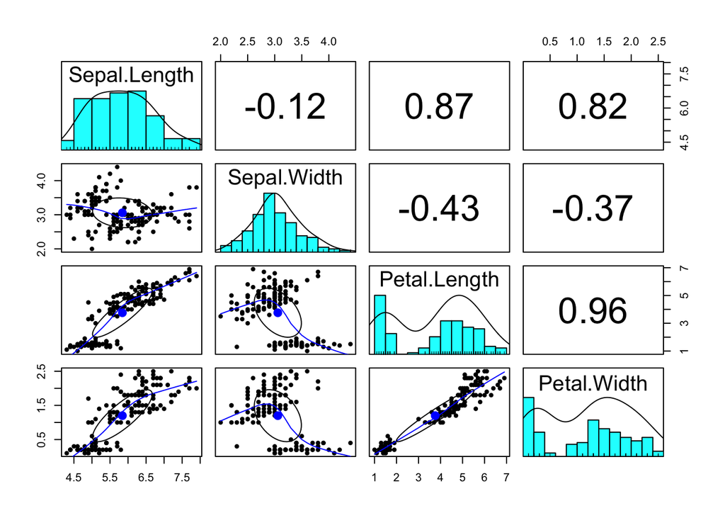

```r
iris %>% select(-Species) %>% pairs.panels()
```

```r
#pairs.panels(iris)
```

## 6.2 scatter plots

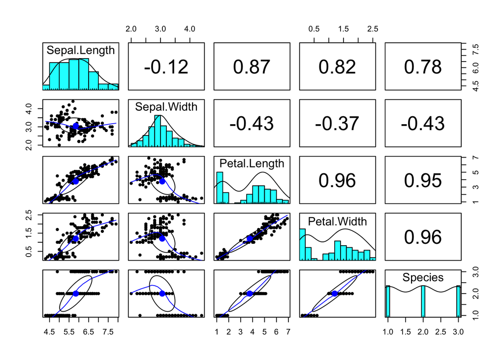

```r
pairs.panels(iris)
```

## 6.3 ggplot simple

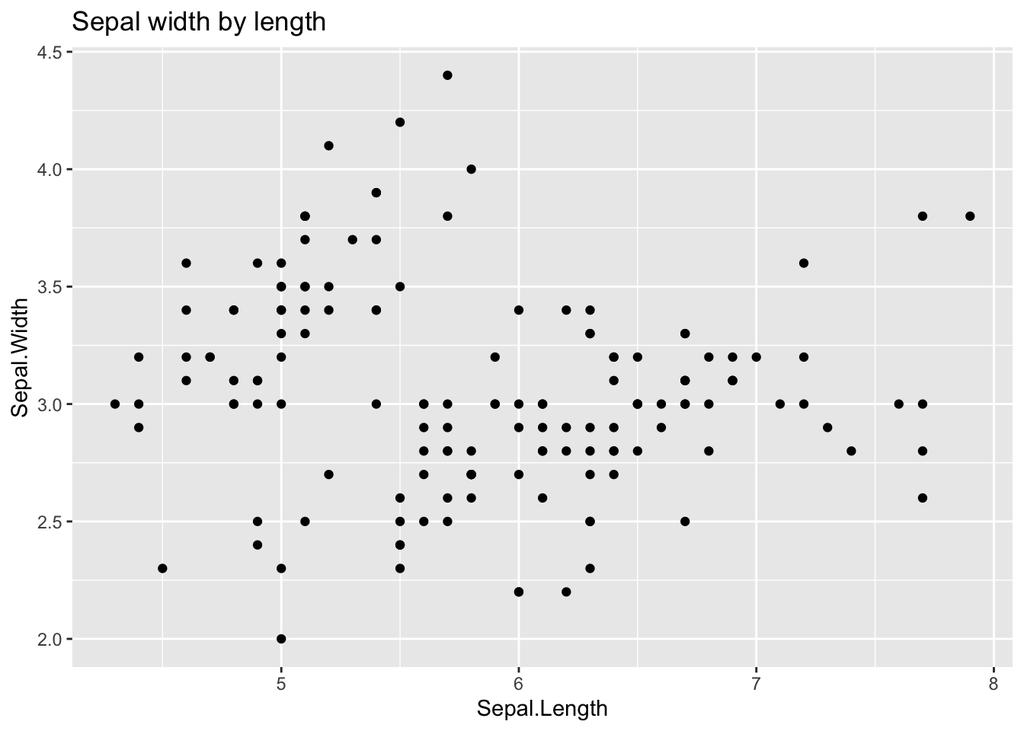

```r
iris %>%
  ggplot() +
  geom_point(aes(x=Sepal.Length,y=Sepal.Width)) +
  ggtitle('Sepal width by length')
```

## 6.4 ggplot with color

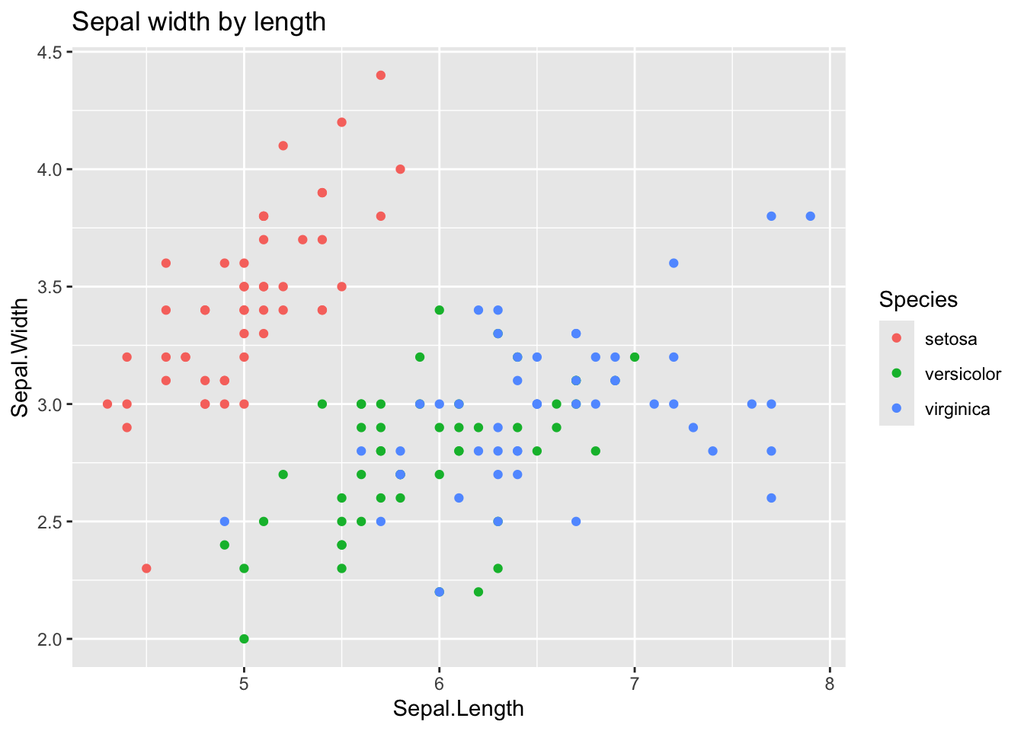

```r
iris %>%
  ggplot() +
  geom_point(aes(x=Sepal.Length,y=Sepal.Width,color=Species)) +
  ggtitle('Sepal width by length')
```

## 6.5 base R with shapes

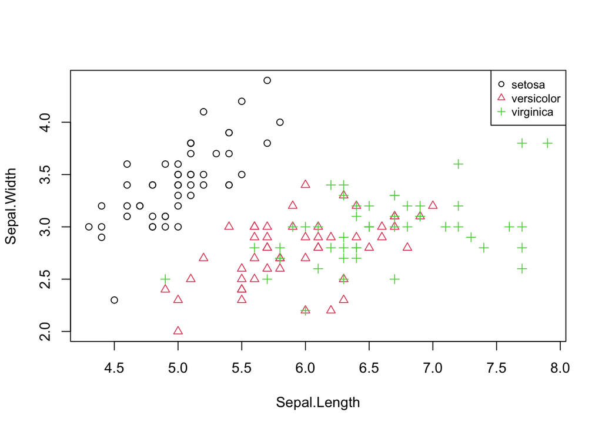

```r
with(iris, plot(Sepal.Length,Sepal.Width, col = Species, pch = as.numeric(Species)))
legend('topright', legend = levels(iris$Species),  col = 1:3, cex = 0.8, pch = 1:3)
```

## 6.6 ggplot with symbols and color and minimal theme

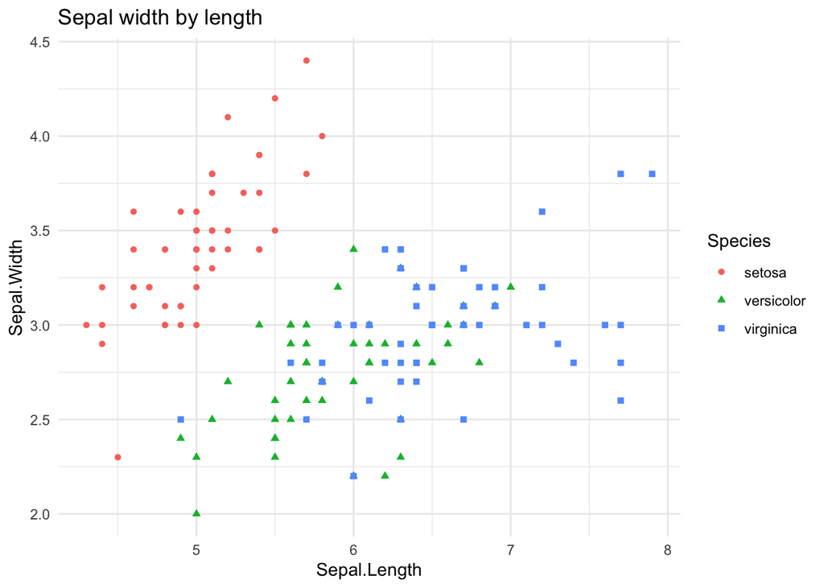

```r
iris %>%
  ggplot() +
  geom_point(aes(x=Sepal.Length,y=Sepal.Width,color=Species,shape=Species)) +
  ggtitle('Sepal width by length') +
  theme_minimal()
```

## 6.7 boxplot by categorical feature

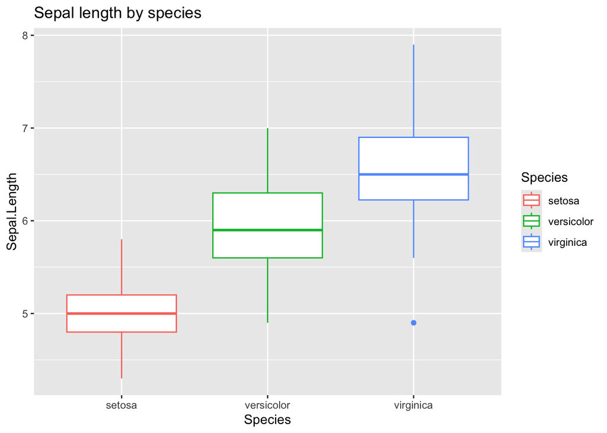

```r
iris %>%
  ggplot() +
  geom_boxplot(aes(x=Species,y=Sepal.Length,color=Species)) +
  ggtitle('Sepal length by species')
```

## 6.8 summaries by categorical (purrr)

purrr <- that’s not a typo it’s a library :)

```r
iris %>% split(.$Species) %>% map(summary)
```

```
## $setosa
##   Sepal.Length    Sepal.Width     Petal.Length    Petal.Width
##  Min.   :4.300   Min.   :2.300   Min.   :1.000   Min.   :0.100
##  1st Qu.:4.800   1st Qu.:3.200   1st Qu.:1.400   1st Qu.:0.200
##  Median :5.000   Median :3.400   Median :1.500   Median :0.200
##  Mean   :5.006   Mean   :3.428   Mean   :1.462   Mean   :0.246
##  3rd Qu.:5.200   3rd Qu.:3.675   3rd Qu.:1.575   3rd Qu.:0.300
##  Max.   :5.800   Max.   :4.400   Max.   :1.900   Max.   :0.600
##        Species
##  setosa    :50
##  versicolor: 0
##  virginica : 0
##
##
##
##
## $versicolor
##   Sepal.Length    Sepal.Width     Petal.Length   Petal.Width          Species
##  Min.   :4.900   Min.   :2.000   Min.   :3.00   Min.   :1.000   setosa    : 0
##  1st Qu.:5.600   1st Qu.:2.525   1st Qu.:4.00   1st Qu.:1.200   versicolor:50
##  Median :5.900   Median :2.800   Median :4.35   Median :1.300   virginica : 0
##  Mean   :5.936   Mean   :2.770   Mean   :4.26   Mean   :1.326
##  3rd Qu.:6.300   3rd Qu.:3.000   3rd Qu.:4.60   3rd Qu.:1.500
##  Max.   :7.000   Max.   :3.400   Max.   :5.10   Max.   :1.800
##
## $virginica
##   Sepal.Length    Sepal.Width     Petal.Length    Petal.Width
##  Min.   :4.900   Min.   :2.200   Min.   :4.500   Min.   :1.400
##  1st Qu.:6.225   1st Qu.:2.800   1st Qu.:5.100   1st Qu.:1.800
##  Median :6.500   Median :3.000   Median :5.550   Median :2.000
##  Mean   :6.588   Mean   :2.974   Mean   :5.552   Mean   :2.026
##  3rd Qu.:6.900   3rd Qu.:3.175   3rd Qu.:5.875   3rd Qu.:2.300
##  Max.   :7.900   Max.   :3.800   Max.   :6.900   Max.   :2.500
##        Species
##  setosa    : 0
##  versicolor: 0
##  virginica :50
##
##
##
```

## 6.9 aggregate

```r
aggregate(Petal.Width~Species, summary, data = iris) # won't show in output
```

```
##      Species Petal.Width.Min. Petal.Width.1st Qu. Petal.Width.Median
## 1     setosa            0.100               0.200              0.200
## 2 versicolor            1.000               1.200              1.300
## 3  virginica            1.400               1.800              2.000
##   Petal.Width.Mean Petal.Width.3rd Qu. Petal.Width.Max.
## 1            0.246               0.300            0.600
## 2            1.326               1.500            1.800
## 3            2.026               2.300            2.500
```

## 6.10 correlation

correlation that won’t run… why not? can you understand why?

```r
#iris %>% cor()
```

```r
iris %>% select(-Species) %>% cor()
```

```
##              Sepal.Length Sepal.Width Petal.Length Petal.Width
## Sepal.Length    1.0000000  -0.1175698    0.8717538   0.8179411
## Sepal.Width    -0.1175698   1.0000000   -0.4284401  -0.3661259
## Petal.Length    0.8717538  -0.4284401    1.0000000   0.9628654
## Petal.Width     0.8179411  -0.3661259    0.9628654   1.0000000
```

```r
iris %>% select(Sepal.Width,Sepal.Length) %>% cor()
```

```
##              Sepal.Width Sepal.Length
## Sepal.Width    1.0000000   -0.1175698
## Sepal.Length  -0.1175698    1.0000000
```

```r
#cor(iris[,c(2,1)])
```

```r
iris %>%
  group_by(Species) %>%
  summarize(cor=cor(Sepal.Width,Sepal.Length))
```

```
## # A tibble: 3 × 2
##   Species      cor
##   <fct>      <dbl>
## 1 setosa     0.743
## 2 versicolor 0.526
## 3 virginica  0.457
```

## 6.11 covariance

```r
iris %>% select(Sepal.Width,Sepal.Length) %>% cov()
```

```
##              Sepal.Width Sepal.Length
## Sepal.Width    0.1899794   -0.0424340
## Sepal.Length  -0.0424340    0.6856935
```

```r
#cov(iris[,c(2,1)])
```

```r
iris %>%
  group_by(Species) %>%
  summarize(cov = cov(Sepal.Width,Sepal.Length))
```

```
## # A tibble: 3 × 2
##   Species       cov
##   <fct>       <dbl>
## 1 setosa     0.0992
## 2 versicolor 0.0852
## 3 virginica  0.0938
```

```r
#cov(iris[,c(2,1)])
```

# 7 That’s all!